# Political Turmoil and Artistic Excellence: Analyzing Government and Cultural Reception

Amithi Pathak

May 10, 2025

### 1. Introduction

Many great artists – whether they be painters, filmmakers, or musicians – are known to have tragic pasts or to have lived during periods of hardship. Hardship in this context could be described by a number of things, including personal issues, economic or financial struggles, or social status. But many of these causes for hardship are affected or even controlled by the larger power in which we live under: the government. And the people’s trust in the government is a reflection of the situations of their livlihood. Using this phenomenon as a basis, this project examines side-by side data of public trust in the US government and the critical/popular reception and trends of film and music in the United States.

### 2. Data Collection and Preparation

For this analysis, I’ve collected data from multiple sources that required different wrangling approaches:

1. Public Approval of the US government: https://www.pewresearch.org/politics/2024/06/24/public-trust-in-government-1958-2024/
2. Movie ratings and metadata from IMBd: https://developer.imdb.com/non-commercial-datasets/
3. Music popularity data from Billboard: https://figshare.com/articles/dataset/Main_Dataset_for_Evolution_of_Popular_Music_USA_1960_2010_/1309953?file=3296294

First I will load the necessary libraries and import my datasets.

Importing film data proved to be a bit more difficult than I had thought. I downloaded the title.akas.tsv.gz, title.basics.tsv.gzm, title.ratings.tsv.gz datasets from IMDb. This is because each dataset had different attributes I wanted to include in a general table. The basics dataset has title, year, and genre information. The akas dataset has region and language, which I needed to filter to only films from the United States. And, of course, I needed the ratings dataset for its rating data for each movie. The problem was, the akas dataset was massive (which makes sense, holding data of all movies across the world since the 1800s). The dataset was so large that even when trying to filter it, I couldn’t import it into Posit Cloud. So, I had to turn to Python using VS code, where I was able to write a script to filter the akas dataset to have region = US. That filtered dataset is what I imported into Posit Cloud. The script is inside the final submission project folder!

### 3 Processing and Analyzing Film Data with Public Trust in Government

This process of filtering to only US movies was enough to shrink down the dataset to import into Posit Cloud. But I still wanted to filter it down even more, because the year scope of the late 1800s was a bit too wide, especially since my public trust data didn’t go that far back. Additionally, I later realized that IMDb recorded data on TV shows. This was marked in the data through a non “NA” value in the endYear column in the basics dataset. So, I went through the process of cleaning this data and making by “master” film table. I started by cleaning the title_basics dataset, converting non-numeric end years to NA and ensuring the startYear values were numeric. Then, I filtered the data to include only movies—with valid start years, no end years, and a release year of 1960 or later. After that, I joined this filtered dataset with title_info to isolate U.S. titles by matching movie IDs. Finally, I merged the result with the title_ratings dataset to incorporate viewer ratings for further analysis.

```
## Rows: 196,057
## Columns: 5
## $ tconst        <chr> "tt0035423", "tt0035423", "tt0035423", "tt0036606", "tt0…
## $ primaryTitle  <chr> "Kate & Leopold", "Kate & Leopold", "Kate & Leopold", "A…
## $ startYear     <dbl> 2001, 2001, 2001, 1983, 1980, 1964, 1961, 1961, 1960, 19…
## $ genres        <chr> "Comedy,Fantasy,Romance", "Comedy,Fantasy,Romance", "Com…
## $ averageRating <dbl> 6.4, 6.4, 6.4, 6.4, 7.4, 3.4, 5.1, 6.9, 6.8, 6.8, 5.8, 5…
```

After that was finalized, I was able to make my first data comparison: film ratings and public trust in government over the years. I first calculated average film ratings by year from the final film dataset, also handling missing values. Then I cleaned the public trust data by parsing dates and calculating yearly averages. After joining these datasets, realized that the public trust data only started in the 1990’s. So, I filtered films to only include years from 1990 onward. The line graph shows how film ratings and public trust in government changed over time, with labeled markers for key historical events to give the reader a feel for what truly occured during rises and drops in these two variables. Finally, I performed a correlation test between average film ratings and public trust levels to quantify their relationship.

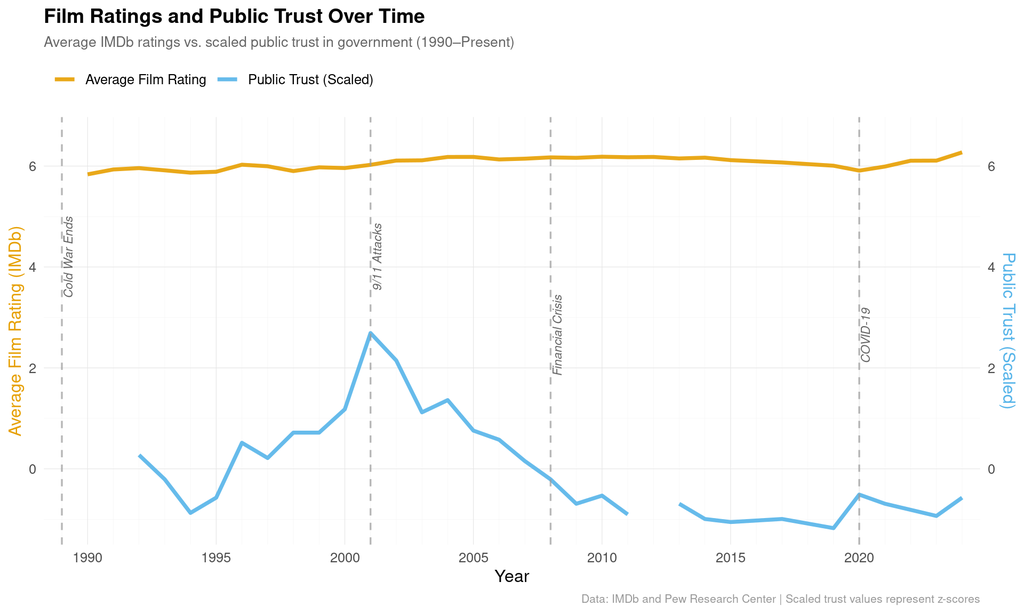

```
##
##  Pearson's product-moment correlation
##
## data:  combined_data_filtered$avg_rating and combined_data_filtered$trust
## t = -0.33206, df = 28, p-value = 0.7423
## alternative hypothesis: true correlation is not equal to 0
## 95 percent confidence interval:
##  -0.4135680  0.3045097
## sample estimates:
##         cor
## -0.06263047
```

Looking at the graph, I believe I overestimated the difference in film ratings over time. Looking back, it’s not like there was a period of time where movies were plain bad. Let’s look at some very slight nuances in movie ratings and line them up with historical events. The most significant decline in public trust in government happened after 9/11/2001. Though not obvious, there was an increase in movie ratings in the few years following. Additionally, public trust dipped after the COVID-19 pandemic in 2020, and so did movie ratings for a while, but in the years after, movie ratings experienced an increase. The movie industry likely needed a healing period amidst lockdown and the lives and jobs lost. Did the nationwide trauma of 9/11 and the pandemic lead to an increase in quality artistic expression? We can’t say for sure soley based on this data alone, but it is something to think about. Just to make sure, I performed a correlation test average film ratings and public trust levels to quantify their relationship. With a correlation of about -0.0626, the weak relationship is quantified, much to my disappointment.

I decided to pivot and examine how film genre popularity and frequency changed over the years. Initial genre data included TV genres, so I first had to filter that out, and added more relevant historical event markers since this graph starts at 1960.

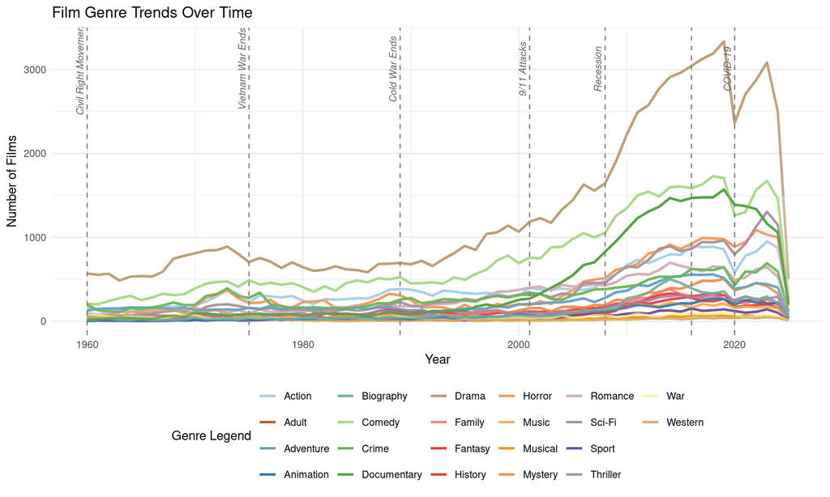

Drama seems to be the perpetual leading category, but soared up compared to others during the 1960’s and 1970’s. Perhaps the Civil Rights Movement and the Vietnam War sparked discourse in the film industry on more serious topics. The second jump in Drama films happens in the late 2000s. Maybe the same thing happened after the stock market crash: the hardships of a recession were reflected in films produced during that time as well. Also notice that the number of documentaries produced rapidly increased after 9/11. Recall how during this period public trust in government dropped as well. Was 9/11 a wakeup call for the production of truthful and alternative journalism? Or perhaps, with the internet debuting in the 1990’s, humans had more ready access to global information, and were taking advantage of their resources.

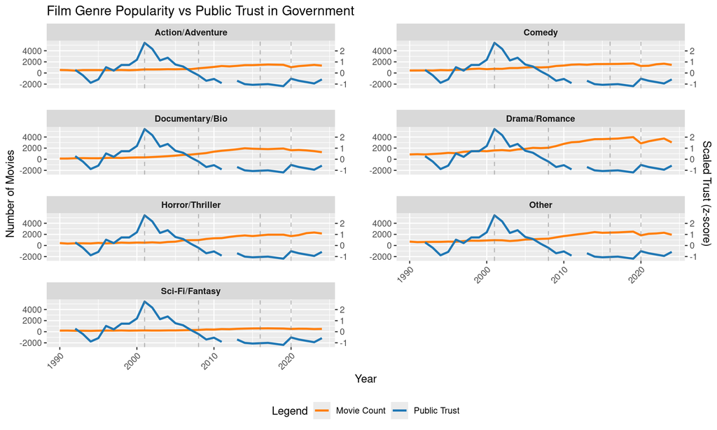

That’s a wrap on analyzing film data. Let’s take a look at music trends.

### 4 Processing and Analyzing Music Data and Public Trust in Government

Instead of year produced, the dataset’s year attribute shows the year the song entered the Billboard charts. So first, I aggregated the music data by year, filtering for 1990 onward to line it up with public trust in government trends. For each year, I calculated the total number of songs and averaged key musical features and topic-based metrics to see shifts in musical style. Next, I merged this with public trust data using inner_join() on the year column, scaling the trust values to normalize them for comparison. Music data I realized too late was a bit limited, to 2010.

For visualization, I wanted to compare trends in song production and entrance on the Billboard charts and societal trust on the same plot, similar to what I did above with film ratings.

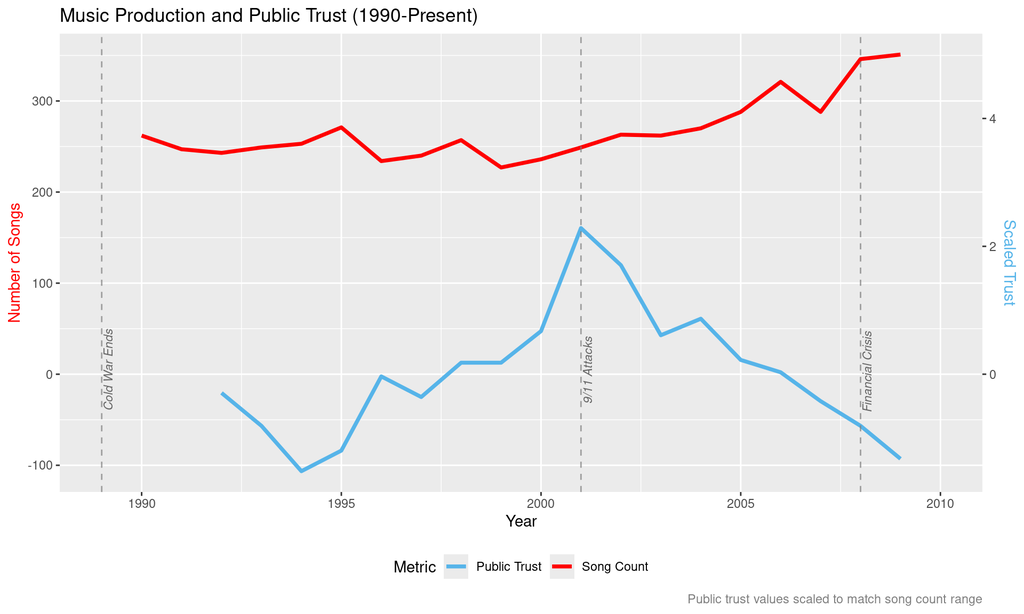

Now let’s delve further into genres. I started by joining music_data with cluster_labels using the cluster column to bring in the genre information. After the join, I converted the genre column to a factor to make it easier to work with in plots. As a debugging measure, I had to reload the music dataset. Otherwise, I’d get re declaration complications.

The source of the dataset mentioned the cluster columns included genre information, but unfortunately didn’t specify what each cluster number meant, so I took it up as a fun challenge to interpret them myself. To get a clearer sense of what each cluster contained, I took a random sample of 10 songs from each cluster. This gave me a straightforward way to validate my cluster interpretations, and I was easily to find a genre group for each cluster, and created a key dataframe mapping cluster to genre. After that, I was able to create two plots visualizing genres of Billboard entries over the years.

```
## # A tibble: 130 × 4
## # Groups:   cluster [13]
##     cluster artist_name                                      track_name     year
##       <int> <chr>                                            <chr>         <int>
##   1       1 "Baby Washington"                                "Only Those …  1965
##   2       1 "Electric Light Orchestra"                       "Showdown"     1973
##   3       1 "Ice Cube"                                       "You Know Ho…  1994
##   4       1 "The Temptations"                                "Since I Los…  1965
##   5       1 "James Brown"                                    "World (Part…  1969
##   6       1 "Frank Sinatra"                                  "River, Stay…  1960
##   7       1 "Sylvia"                                         "Didn't I"     1973
##   8       1 "Jaheim"                                         "Put That Wo…  2003
##   9       1 "Garland Green"                                  "Jealous Kin…  1969
##  10       1 "Timi Yuro"                                      "Smile"        1961
##  11       2 "Freeway Featuring Peedi Crakk"                  "Flipside"     2003
```

[output cut: 119 more lines]

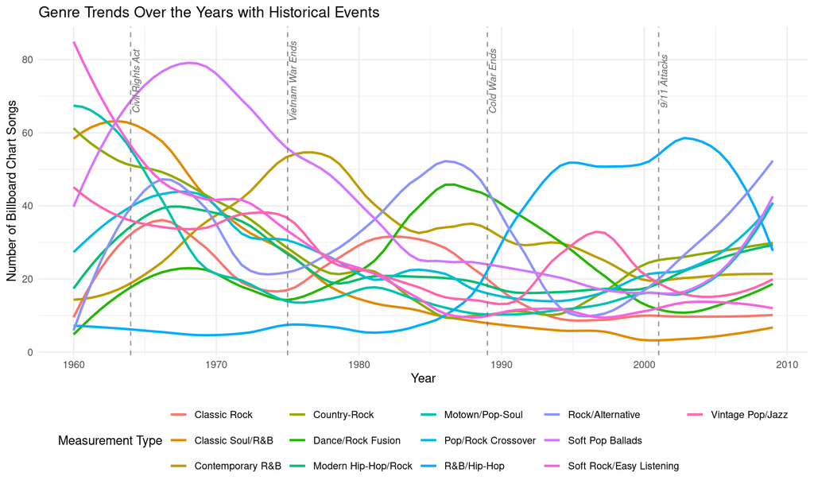

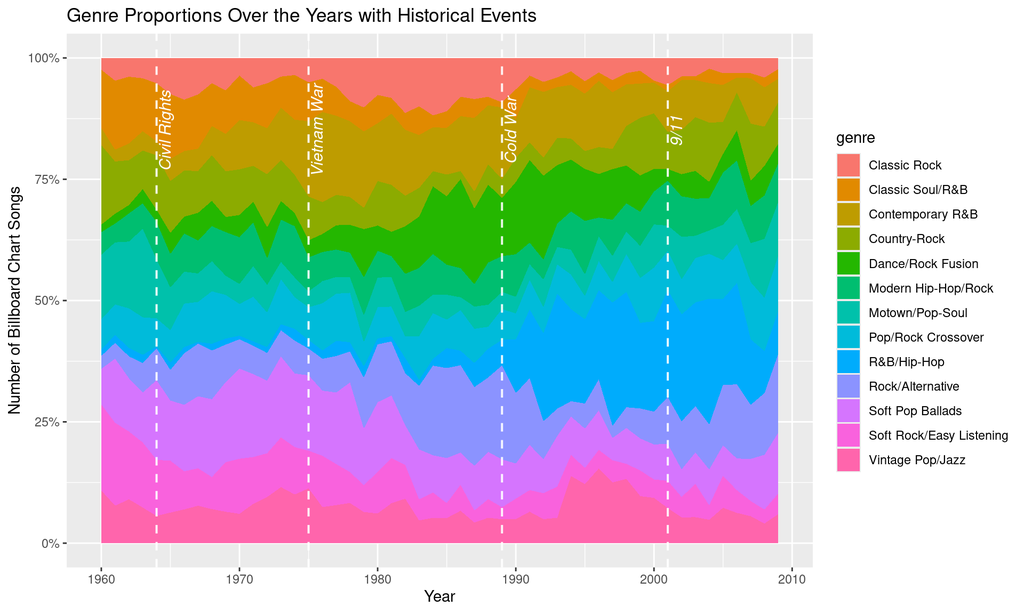

You can see Soft Pop Ballads dominated the late 60s/early 70s before falling off, while R&B/Hip-Hop stayed relatively quiet until skyrocketing in the late 80s and 90s, a known cultural revolution known as the “Golden Age” of rap. This comes after the Civil Rights Movement and end of the Cold War, where people of color were able to more express themselves more on mainstream media, a stark contract to my initial hypothesis of only bad times producing quality music.

[figure not shown]

### 5 Conclusion

In the end, the data didn’t give a clear answer to my initial question of whether political turmoil leads to better quality music, and more analysis was more speculative than anything. But I did uncover some interesting patterns. I saw shifts in public trust in government that seemed to line up with changes in how music and films are rated, produced, and what kinds of genres were popular. So while the original question wasn’t fully answered, the trends found show that there’s definitely a lot to dig into, and it’s a good start.